# DESCO - Knowledge Discovery - Forecast responses to future campaigns

## 1. Exploracao e preparacao dos dados

Nesta fase e após termos os valores de *RFM*, vamos iniciar o processo de análise e preparação dos dados para a fase de classificação.

#### Tabela CAMPAIGN.DAT

Após o carregamento da tabela *CAMPAIGN.dat*

```r
campaign <- read.table("DATA-CRM/CAMPAIGN.dat", header = TRUE, sep = ",", dec = ",")
```

É necessário efetuar a verificacao dos dados da tabela *CAMPAIGN.dat*, tal como o número de colunas e linhas, bem como se os dados foram corretamente carregados.

Verificar se a tabela possui dados nulos, o que não acontece. Esta tabela é muito simples e não houve dados a corrigir.

#### Tabela CARD.dat

Carregamento da tabela *CARD.dat* bem como a sua transformação para *Data Table* para facilitar o tratamento posteriormente.

```r
card <- read.table("DATA-CRM/CARD.dat", header = TRUE, sep = ",", dec = ",")
setDT(card)
```

Verificacao dos dados da tabela card, tal como o número de colunas e linhas, bem como se os dados foram corretamente carregados. Podemos verificar alguns dados como *NumChildren* e *YoungestChild* que possuem dados negativos e que será necessário corrigir. No atributo *MaritalStatus* verificamos a existência de dados nulos.

```r
summary(card)
```

```
##          CardID                City           Region
##  C0100000111:     1   Catburg    :23479   Central:70199
##  C0100000113:     1   Foxton     :23073   Eastern:69933
##  C0100000199:     1   Kingsville :23533
##  C0100000267:     1   Princeton  :23397
##  C0100000289:     1   Queensbury :23269
##  C0100000343:     1   Ravensville:23381
##  (Other)    :140126
##     PostalCode     CardStartDate      Gender     DateOfBirth
##  A039798 :  9751   Min.   :19980101   F:70109   Min.   :19020128
##  A001761 :  1253   1st Qu.:19981121   M:70023   1st Qu.:19541016
##  A024496 :  1017   Median :19991011             Median :19620106
##  A0104173:   634   Mean   :19993808             Mean   :19609787
##  A049814 :   606   3rd Qu.:20000830             3rd Qu.:19690220
##  A0117302:   597   Max.   :20011231             Max.   :19911211
##  (Other) :126274
##  MaritalStatus HasChildren  NumChildren     YoungestChild
##   :46914       N:69062     Min.   :-1.000   Min.   :-6.00
##  M:46539       Y:71070     1st Qu.: 0.000   1st Qu.: 2.00
##  S:46679                   Median : 1.000   Median :10.00
##                            Mean   : 1.106   Mean   :11.26
##                            3rd Qu.: 2.000   3rd Qu.:17.00
##                            Max.   : 7.000   Max.   :73.00
##
```

```r
dim(card)
```

```
## [1] 140132     11
```

```r
str(card)
```

```
## Classes 'data.table' and 'data.frame':   140132 obs. of  11 variables:
##  $ CardID       : Factor w/ 140132 levels "C0100000111",..: 84335 50606 55095 105285 100144 44627 47864 94724 4328 4316 ...
##  $ City         : Factor w/ 6 levels "Catburg","Foxton",..: 6 1 4 5 4 3 6 4 1 3 ...
##  $ Region       : Factor w/ 2 levels "Central","Eastern": 2 2 1 1 1 1 2 1 2 1 ...
##  $ PostalCode   : Factor w/ 55391 levels "A000003","A000004",..: 45825 45825 45825 45825 45825 45825 45825 45825 27358 27358 ...
##  $ CardStartDate: int  19990929 20011114 19980502 19990329 20001112 20000205 20011001 20010911 19980331 20000916 ...
##  $ Gender       : Factor w/ 2 levels "F","M": 1 1 2 2 2 1 2 2 1 1 ...
##  $ DateOfBirth  : int  19590329 19670327 19671224 19441107 19570813 19570416 19820515 19550716 19650521 19610417 ...
##  $ MaritalStatus: Factor w/ 3 levels "","M","S": 2 1 3 3 3 1 2 1 2 1 ...
##  $ HasChildren  : Factor w/ 2 levels "N","Y": 2 1 1 1 2 1 2 1 2 2 ...
##  $ NumChildren  : int  5 0 0 0 1 0 1 0 2 5 ...
##  $ YoungestChild: int  12 2 8 27 15 14 0 15 8 10 ...
##  - attr(*, ".internal.selfref")=<externalptr>
```

```r
nrow(card[!complete.cases(card),])
```

```
## [1] 0
```

```r
table(is.na(card))
```

```
##
##   FALSE
## 1541452
```

```r
unique(card)
```

```
##              CardID        City  Region PostalCode CardStartDate Gender
##      1: C0103967350 Ravensville Eastern    A074282      19990929      F
##      2: C0102378887     Catburg Eastern    A074282      20011114      F
##      3: C0102589553   Princeton Central    A074282      19980502      M
##      4: C0104955317  Queensbury Central    A074282      19990329      M
##      5: C0104710149   Princeton Central    A074282      20001112      M
##     ---
## 140128: C0102011648  Kingsville Central    A039798      19990412      F
## 140129: C0100502410   Princeton Central    A039798      19980420      M
## 140130: C0102534365  Kingsville Central    A039798      19980503      F
## 140131: C0101070581     Catburg Eastern    A039798      19980319      F
## 140132: C0103023359  Kingsville Central    A039798      19981224      M
##         DateOfBirth MaritalStatus HasChildren NumChildren YoungestChild
##      1:    19590329             M           Y           5            12
##      2:    19670327                         N           0             2
##      3:    19671224             S           N           0             8
##      4:    19441107             S           N           0            27
##      5:    19570813             S           Y           1            15
##     ---
## 140128:    19710729             M           Y           1             0
## 140129:    19640414             S           N           0             3
## 140130:    19770724             M           N           0             0
## 140131:    19470410                         N           0            23
## 140132:    19690512                         N           1             0
```

```r
table(duplicated(card))
```

```
##
##  FALSE
## 140132
```

Tratamento os dados nulos e errados nas colunas *NumChildren* e *YoungestChild* , pois existem valores negativos. No *MaritalStatus* há dados nulos que devem ser tratados também.

Colocamos a zeros os valores abaixo de zero de *NumChildren* e *YoungestChild*. Também decidimos fazer uma correção quando diz que o número de filhos é zero e depois indica que tem filhos.

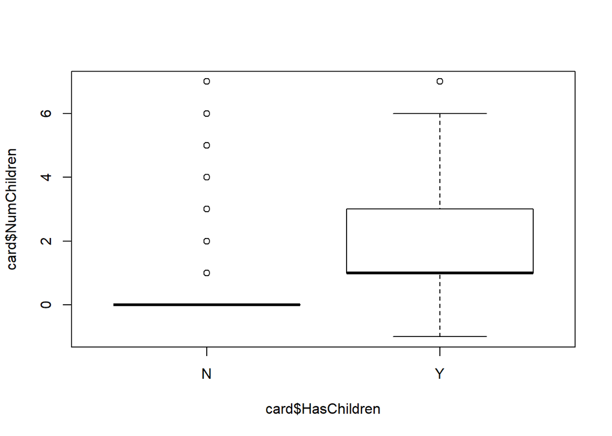

```r
# Podemos verifica que existem alguns registos, caracterizados como outliers, que indicam que não tem filhos mas depois no atributo *NumChildren* existe um valor superior a zero.
plot(card$NumChildren~card$HasChildren)
```

```r
card$NumChildren[card$NumChildren < 0] <- 0
table(card$NumChildren)
```

```
##
##     0     1     2     3     4     5     6     7
## 60937 41226 17472 10442  6299  1766   527  1463
```

```r
card$YoungestChild[card$YoungestChild < 0] <- 0
table(card$YoungestChild)
```

```
##
##     0     1     2     3     4     5     6     7     8     9    10    11
## 28521  3604  3790  4153  4372  4698  4892  5137  5263  5476  5336  5246
##    12    13    14    15    16    17    18    19    20    21    22    23
##  4971  4876  4654  4258  3925  3651  3397  3102  2783  2622  2271  2029
##    24    25    26    27    28    29    30    31    32    33    34    35
##  1875  1742  1551  1337  1172  1064   913   814   747   630   572   492
##    36    37    38    39    40    41    42    43    44    45    46    47
##   480   427   384   378   330   294   285   222   185   173   156   144
##    48    49    50    51    52    53    54    55    56    57    58    59
##   122   118    85    73    80    49    37    35    20    13    10     9
##    60    61    62    63    64    65    66    67    68    69    70    71
##     9     8    13    10     9     6     7     8     5     3     1     3
##    72    73
##     3     2
```

```r
## Como existem observacões que indicam ter filhos, mas depois o campo do número de filhos esta a 0, decidimos alterar o atributo "HasChildren" para "N"
card[card$NumChildren == 0 & card$HasChildren == 'Y', .N]
```

```
## [1] 13
```

```r
card$HasChildren[card$NumChildren == 0] <- 'N'


## NumChildren>0 e HasChildren
card[card$NumChildren > 0 & card$HasChildren == 'N', .N]
```

```
## [1] 8138
```

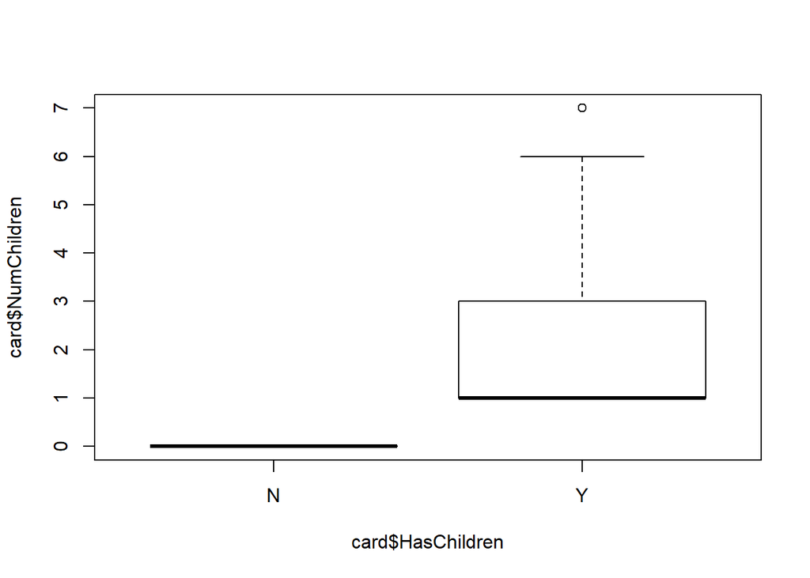

```r
# Verificamos que ficou corrigido, em que agora todos os registos em que *HasChildren* está a N, o *NumChildren* está a zero.
card$HasChildren[card$NumChildren > 0] <- 'Y'
plot(card$NumChildren~card$HasChildren)
```

```r
## Corrigir os dados de *MaritalStatus* sem valor, para não escolher aleatóriamente o Casado ou Solteiro, decidimos criar o atributo Outro.
table(card$MaritalStatus)
```

```
##
##           M     S
## 46914 46539 46679
```

```r
card[MaritalStatus == "", MaritalStatus := "O"]
card$MaritalStatus <- droplevels(card$MaritalStatus)
```

## 2. Pré-processamento dos dados

Após o tratamento dos dados é agora necessário a preparação dos mesmos para a aplicação dos algoritmos de classificação.

#### Merge das tabelas dos dados dos clientes *CARD.dat* com os valores de *RFM* obtidos anteriormente

```r
# Juntar o resultado do RFM com a tabela card numa nova tabela
df_card <- merge(card, rfm_result$rfm[,c(1,9)], by.x = 'CardID', by.y = 'customer_id')

# Agora juntar o nosso atributo a prever que se encontra da tabela *CAMPAIGN.dat*
df_card <- merge(df_card, campaign, by = 'CardID')

# Tratamento das datas para data no novo data frame
df_card[, CardStartDate := as.Date(as.character.Date(CardStartDate),"%Y%m%d")]
df_card[, DateOfBirth := as.Date(as.character.Date(DateOfBirth),"%Y%m%d")]
```

Como será mais facil trabalhar os dados com um valor absoluto em vez das datas de idade e data de início de cliente, decidimos trocar estes atributos, usado a variável **analysis_date**, anteriormente definida.

```r
# Criar a idade do cliente em valor absoluto
yr = duration(num = 1, units = "years")
df_card[, age := round(interval(DateOfBirth, analysis_date)/yr,digits = 0)][]
```

```
##             CardID        City  Region PostalCode CardStartDate Gender
##     1: C0100000392  Kingsville Central   A0104173    2000-09-09      F
##     2: C0100000482     Catburg Eastern    A051507    1999-08-25      F
##     3: C0100000586   Princeton Central    A040032    1999-11-19      M
##     4: C0100000726      Foxton Eastern    A001761    2000-11-01      F
##     5: C0100000789  Queensbury Central    A039798    1999-09-20      M
##    ---
## 12195: C0106595037   Princeton Central    A066446    2001-12-19      F
## 12196: C0106596188  Queensbury Central    A080606    1998-07-17      M
## 12197: C0106596320      Foxton Eastern    A075306    1998-01-28      M
## 12198: C0106596462 Ravensville Eastern    A082714    2001-08-04      F
## 12199: C0106596868      Foxton Eastern    A095681    1999-11-24      F
##        DateOfBirth MaritalStatus HasChildren NumChildren YoungestChild
##     1:  1970-04-21             S           Y           1             0
##     2:  1963-03-16             S           Y           1             6
```

[output cut: 21 more lines]

```r
# Anos de clientes, há quanto tempo é cliente
df_card[, clientYears := round(interval(CardStartDate, analysis_date)/yr,digits = 0)][]
```

```
##             CardID        City  Region PostalCode CardStartDate Gender
##     1: C0100000392  Kingsville Central   A0104173    2000-09-09      F
##     2: C0100000482     Catburg Eastern    A051507    1999-08-25      F
##     3: C0100000586   Princeton Central    A040032    1999-11-19      M
##     4: C0100000726      Foxton Eastern    A001761    2000-11-01      F
##     5: C0100000789  Queensbury Central    A039798    1999-09-20      M
##    ---
## 12195: C0106595037   Princeton Central    A066446    2001-12-19      F
## 12196: C0106596188  Queensbury Central    A080606    1998-07-17      M
## 12197: C0106596320      Foxton Eastern    A075306    1998-01-28      M
## 12198: C0106596462 Ravensville Eastern    A082714    2001-08-04      F
## 12199: C0106596868      Foxton Eastern    A095681    1999-11-24      F
##        DateOfBirth MaritalStatus HasChildren NumChildren YoungestChild
##     1:  1970-04-21             S           Y           1             0
##     2:  1963-03-16             S           Y           1             6
```

[output cut: 21 more lines]

```r
# Visualização dos dados
summary(df_card)
```

```
##          CardID               City          Region        PostalCode
##  C0100000392:    1   Catburg    :2073   Central:6084   A039798 :  903
##  C0100000482:    1   Foxton     :2044   Eastern:6115   A001761 :  136
##  C0100000586:    1   Kingsville :2104                  A024496 :  104
##  C0100000726:    1   Princeton  :1975                  A0104173:   77
##  C0100000789:    1   Queensbury :2005                  A0117302:   54
##  C0100001467:    1   Ravensville:1998                  A049814 :   46
##  (Other)    :12193                                     (Other) :10879
##  CardStartDate        Gender    DateOfBirth         MaritalStatus
##  Min.   :1998-01-01   F:6077   Min.   :1905-03-16   M:4010
##  1st Qu.:1998-10-30   M:6122   1st Qu.:1954-11-05   S:4110
##  Median :1999-09-01            Median :1962-01-07   O:4079
##  Mean   :1999-09-19            Mean   :1961-06-21
##  3rd Qu.:2000-07-03            3rd Qu.:1969-02-02
##  Max.   :2001-12-28            Max.   :1991-11-30
##
##  HasChildren  NumChildren    YoungestChild     rfm_score
##  N:5319      Min.   :0.000   Min.   : 0.00   Min.   :111.0
##  Y:6880      1st Qu.:0.000   1st Qu.: 2.00   1st Qu.:214.0
##              Median :1.000   Median :10.00   Median :325.0
##              Mean   :1.141   Mean   :11.18   Mean   :330.3
##              3rd Qu.:2.000   3rd Qu.:17.00   3rd Qu.:454.0
##              Max.   :7.000   Max.   :66.00   Max.   :555.0
##
##  Responded            age          clientYears
##  Mode :logical   Min.   : 23.00   Min.   :13.00
##  FALSE:9800      1st Qu.: 46.00   1st Qu.:15.00
##  TRUE :2399      Median : 53.00   Median :15.00
##                  Mean   : 53.57   Mean   :15.27
##                  3rd Qu.: 60.00   3rd Qu.:16.00
##                  Max.   :110.00   Max.   :17.00
##
```

Agora vamos eliminar dados desnecessários do data frame

```r
# Remoção dos campos de *PostalCode*, CardStartDate e DateOfBirth.
df_card <- df_card[, c(2,3,6,8:15)]

## Mudar o atributo objetivo para o fim da tabela
df_card <- df_card[, c(1:8,10,11,9)]

str(df_card)
```

```
## Classes 'data.table' and 'data.frame':   12199 obs. of  11 variables:
##  $ City         : Factor w/ 6 levels "Catburg","Foxton",..: 3 1 4 2 5 3 3 5 5 2 ...
##  $ Region       : Factor w/ 2 levels "Central","Eastern": 1 2 1 2 1 1 1 1 1 2 ...
##  $ Gender       : Factor w/ 2 levels "F","M": 1 1 2 1 2 1 1 2 1 2 ...
##  $ MaritalStatus: Factor w/ 3 levels "M","S","O": 2 2 3 1 1 3 3 1 3 2 ...
##  $ HasChildren  : Factor w/ 2 levels "N","Y": 2 2 1 2 2 2 1 2 2 1 ...
##  $ NumChildren  : num  1 1 0 1 1 3 0 2 1 0 ...
##  $ YoungestChild: num  0 6 30 21 6 0 10 0 15 11 ...
##  $ rfm_score    : num  555 432 454 455 525 423 511 334 521 214 ...
##  $ age          : num  45 52 74 59 53 43 54 43 59 52 ...
##  $ clientYears  : num  14 15 15 14 15 17 13 15 15 15 ...
##  $ Responded    : logi  TRUE TRUE TRUE FALSE FALSE FALSE ...
##  - attr(*, ".internal.selfref")=<externalptr>
```

Para uma mais fácil leitura decidimos criar novos fatores nos atributos *Gender*, *MaritalStatus*, *HasChildren* e *Responded*.

```r
df_card$Gender <- factor(df_card$Gender, levels = c("F", "M"), labels = c("Feminino", "Masculino"))
df_card$MaritalStatus <- factor(df_card$MaritalStatus, levels = c("M", "S", "O"), labels = c("Casado", "Solteiro", "Outro"))
df_card$HasChildren <- factor(df_card$HasChildren, levels = c("Y", "N"), labels = c("Sim","Nao"))
df_card$Responded <- factor(df_card$Responded, levels = c(TRUE, FALSE), labels = c("Sim","Nao"))
```

### Visualizacao dos dados para análise

```r
summary(df_card)
```

```
##           City          Region           Gender      MaritalStatus
##  Catburg    :2073   Central:6084   Feminino :6077   Casado  :4010
##  Foxton     :2044   Eastern:6115   Masculino:6122   Solteiro:4110
##  Kingsville :2104                                   Outro   :4079
##  Princeton  :1975
##  Queensbury :2005
##  Ravensville:1998
##  HasChildren  NumChildren    YoungestChild     rfm_score
##  Sim:6880    Min.   :0.000   Min.   : 0.00   Min.   :111.0
##  Nao:5319    1st Qu.:0.000   1st Qu.: 2.00   1st Qu.:214.0
##              Median :1.000   Median :10.00   Median :325.0
##              Mean   :1.141   Mean   :11.18   Mean   :330.3
##              3rd Qu.:2.000   3rd Qu.:17.00   3rd Qu.:454.0
##              Max.   :7.000   Max.   :66.00   Max.   :555.0
##       age          clientYears    Responded
##  Min.   : 23.00   Min.   :13.00   Sim:2399
##  1st Qu.: 46.00   1st Qu.:15.00   Nao:9800
##  Median : 53.00   Median :15.00
##  Mean   : 53.57   Mean   :15.27
##  3rd Qu.: 60.00   3rd Qu.:16.00
##  Max.   :110.00   Max.   :17.00
```

```r
str(df_card)
```

```
## Classes 'data.table' and 'data.frame':   12199 obs. of  11 variables:
##  $ City         : Factor w/ 6 levels "Catburg","Foxton",..: 3 1 4 2 5 3 3 5 5 2 ...
##  $ Region       : Factor w/ 2 levels "Central","Eastern": 1 2 1 2 1 1 1 1 1 2 ...
##  $ Gender       : Factor w/ 2 levels "Feminino","Masculino": 1 1 2 1 2 1 1 2 1 2 ...
##  $ MaritalStatus: Factor w/ 3 levels "Casado","Solteiro",..: 2 2 3 1 1 3 3 1 3 2 ...
##  $ HasChildren  : Factor w/ 2 levels "Sim","Nao": 1 1 2 1 1 1 2 1 1 2 ...
##  $ NumChildren  : num  1 1 0 1 1 3 0 2 1 0 ...
##  $ YoungestChild: num  0 6 30 21 6 0 10 0 15 11 ...
##  $ rfm_score    : num  555 432 454 455 525 423 511 334 521 214 ...
##  $ age          : num  45 52 74 59 53 43 54 43 59 52 ...
##  $ clientYears  : num  14 15 15 14 15 17 13 15 15 15 ...
##  $ Responded    : Factor w/ 2 levels "Sim","Nao": 1 1 1 2 2 2 2 1 2 2 ...
##  - attr(*, ".internal.selfref")=<externalptr>
```

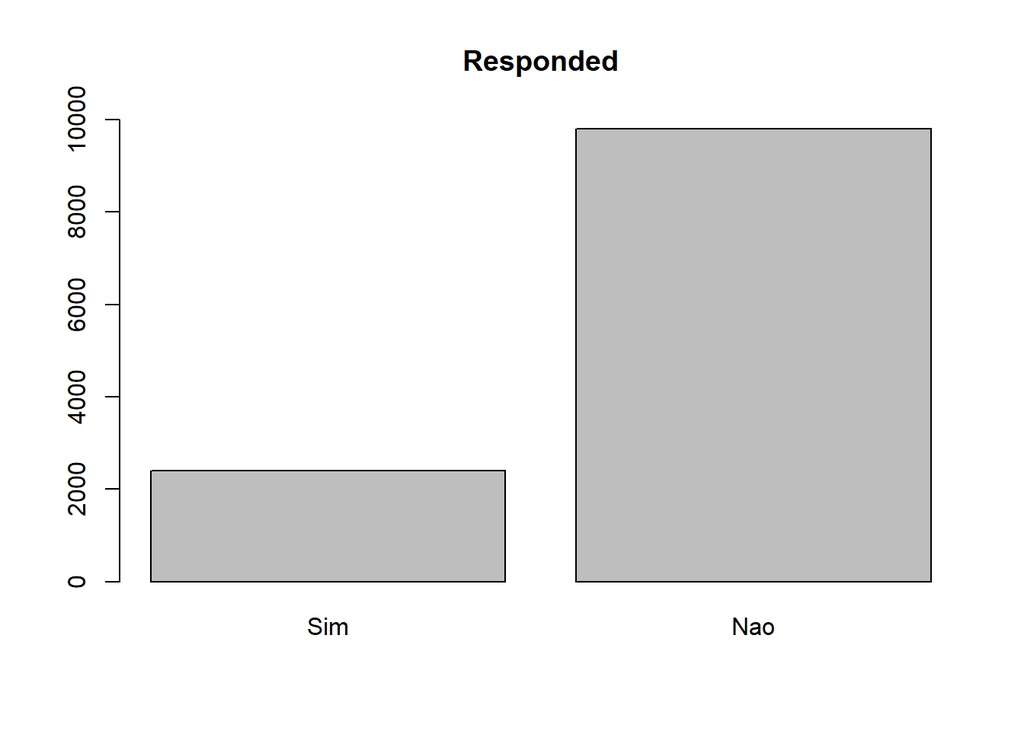

```r
## Verificar a percentagem de clientes que responderam a campanha
barplot(table(df_card$Responded), ylim = c(0,10000), main = "Responded")
```

```r
round(prop.table(table(df_card$Responded))*100,digits = 2)
```

```
##
##   Sim   Nao
## 19.67 80.33
```

Podemos verificar que a proporção de *Sim* e *Não* está muito desbalanceada, pelo que irá ser necessário fazer algo para balancear as proporções, visto que alguns algoritmos não vão conseguir prever o *Sim*, devido à baixa percentagem de ocorrência.

## 3. Criação da função para avaliação de modelos de Data-Mining e data-frame para guardar os resultados.

```r
##Funcao para avaliacao dos modelos e data frame para guardar os dados

allcrosstabmeasures <- function (tst_labels, pred_labels, modelname=""){
  if (length(unique(tst_labels)) == length(unique(pred_labels))) {
    ctmatrix <- CrossTable(tst_labels,pred_labels,prop.chisq = FALSE, prop.c = FALSE, prop.r = FALSE, dnn = c("Real","Predicted"))
    accuracy <- sum(diag(ctmatrix$t))/sum(ctmatrix$t)
    recall <- ctmatrix[[1]][1,1]/sum(ctmatrix[[1]][1,]) ##TPR Recall
    precision <- ctmatrix[[1]][1,1]/sum(ctmatrix[[1]][,1])
    fpr <- ctmatrix[[1]][2,1]/sum(ctmatrix[[1]][2,])
    f1 <- 2*precision*recall/(precision+recall)
    pre <- (sum(ctmatrix[[1]][1,])/sum(ctmatrix$t)*sum(ctmatrix[[1]][,1])/sum(ctmatrix$t)) + (sum(ctmatrix[[1]][2,])/sum(ctmatrix$t)*sum(ctmatrix[[1]][,2])/sum(ctmatrix$t))
  kappa <- (accuracy - pre) / (1-pre)
  data.frame(model=modelname,accuracy=round(accuracy,digits = 3),recall=round(recall,digits = 3),precision=round(precision,digits = 3),f1=round(f1,digits = 3), kappa=round(kappa,digits = 3),fpr=round(fpr,digits = 3))
  } else {
    stop("Erro na construcao do modelo")
  }
}


## Declara um data frame para guardar os dados estatisticos
results.df <- data.frame(model = character(),
                         accuracy = double(),
                         recall = double(),
                         precision = double(),
                         f1 = double(),
                         kappa = double(),
                         fpr = double(),
                         stringsAsFactors = FALSE)
```

#### Devido a taxa de *Sim* no atributo *Responded* ser inferior a 20%, foi necessario efetuar um Oversamppling dos dados positivos para equilibrar os mesmos.

### Holdout stratified

A divisão dos dados é feita considerando 70% dos mesmos para treino dos modelos e posteriormente os restantes 30% para a evaliação. O Oversampling apenas aplicado ao conjunto do treino, serve assim para colocar os valores de *sim* e *não* em percetagens equivalentes na contrução do modelo.

```r
## Holdout stratified

set.seed(123)


##create of stratified train/test partitions
train.idx <- createDataPartition(df_card$Responded, p = 0.7, list = F)

trainSet <- df_card[ train.idx, ]
tstSet <-   df_card[-train.idx, ]
attach(trainSet)

## Criar o oversampling para resolver o problema dos dados desbalanceados.
oversampling <- trainSet[ which(trainSet$Responded=='Sim'),]
trainSet <- rbind(trainSet,oversampling)
trainSet <- rbind(trainSet,oversampling)
table(trainSet$Responded)
```

```
##
##  Sim  Nao
## 5040 6860
```

```r
summary(trainSet)
```

```
##           City          Region           Gender      MaritalStatus
##  Catburg    :2053   Central:5977   Feminino :5943   Casado  :3912
##  Foxton     :1955   Eastern:5923   Masculino:5957   Solteiro:3960
##  Kingsville :2056                                   Outro   :4028
##  Princeton  :1964
##  Queensbury :1957
##  Ravensville:1915
##  HasChildren  NumChildren    YoungestChild     rfm_score
##  Sim:6733    Min.   :0.000   Min.   : 0.00   Min.   :111.0
##  Nao:5167    1st Qu.:0.000   1st Qu.: 2.00   1st Qu.:213.0
##              Median :1.000   Median : 9.00   Median :325.0
##              Mean   :1.135   Mean   :11.19   Mean   :331.2
##              3rd Qu.:2.000   3rd Qu.:17.00   3rd Qu.:455.0
##              Max.   :7.000   Max.   :66.00   Max.   :555.0
##       age          clientYears    Responded
##  Min.   : 23.00   Min.   :13.00   Sim:5040
##  1st Qu.: 46.00   1st Qu.:15.00   Nao:6860
##  Median : 53.00   Median :15.00
##  Mean   : 53.59   Mean   :15.34
##  3rd Qu.: 60.00   3rd Qu.:16.00
##  Max.   :110.00   Max.   :17.00
```

```r
table(trainSet$Responded)
```

```
##
##  Sim  Nao
## 5040 6860
```

```r
round(prop.table(table(trainSet$Responded))*100, digits = 2)
```

```
##
##   Sim   Nao
## 42.35 57.65
```

```r
train_labels <- trainSet$Responded
tst_labels <- tstSet$Responded

round(prop.table(table(train_labels))*100, digits = 2)
```

```
## train_labels
##   Sim   Nao
## 42.35 57.65
```

```r
round(prop.table(table(tst_labels))*100, digits = 2)
```

```
## tst_labels
##   Sim   Nao
## 19.65 80.35
```

```r
ncols <- dim(trainSet)[2]
ctrl <- trainControl(method = "cv", number = 10)
```

## 4. Algoritmos de classificação

### Método de classificação C5.0

```r
set.seed(123)

modelLookup(model = "C5.0") # Função para verificar as possibilidades do modelo

C5Model <- C5.0(Responded~.,data = trainSet)

summary(C5Model)

C5Predict <- predict(C5Model,newdata = tstSet,type = "class")

results.df <- rbind(results.df,allcrosstabmeasures(tst_labels,C5Predict,"C5.0 Classif."))
results.df
```

```
    Attribute usage:

    100.00% clientYears
     93.74% rfm_score
     87.66% City
     58.82% YoungestChild
     49.04% MaritalStatus
     48.63% age
     47.55% NumChildren
     19.44% Gender
     14.50% HasChildren
      5.09% Region
```

A matriz de confusão que nos permite ter acesso às medidas de avaliação dos modelos criados:

```
             | Predicted
        Real |       Sim |       Nao | Row Total |
-------------|-----------|-----------|-----------|
         Sim |       282 |       437 |       719 |
             |     0.077 |     0.119 |           |
-------------|-----------|-----------|-----------|
         Nao |       806 |      2134 |      2940 |
             |     0.220 |     0.583 |           |
-------------|-----------|-----------|-----------|
Column Total |      1088 |      2571 |      3659 |
-------------|-----------|-----------|-----------|
```

### Método C5.0 com função treino

```r
## C5.0 com funcao treino
set.seed(123)


##grade de parametros para otimizar o algoritmo
grid <- expand.grid(winnow = c(TRUE,FALSE), trials = c(1,2,10,15,20), model = "tree")
grid
```

```
##    winnow trials model
## 1    TRUE      1  tree
## 2   FALSE      1  tree
## 3    TRUE      2  tree
## 4   FALSE      2  tree
## 5    TRUE     10  tree
## 6   FALSE     10  tree
## 7    TRUE     15  tree
## 8   FALSE     15  tree
## 9    TRUE     20  tree
## 10  FALSE     20  tree
```

```r
C5model <- train(Responded~.,data = trainSet,
                 method = 'C5.0',
                 metric = 'Accuracy',
                 trControl = ctrl,
                 tuneGrid = grid)
C5model
```

```
## C5.0
##
## 11900 samples
##    10 predictor
##     2 classes: 'Sim', 'Nao'
##
## No pre-processing
## Resampling: Cross-Validated (10 fold)
## Summary of sample sizes: 10710, 10710, 10710, 10710, 10710, 10710, ...
## Resampling results across tuning parameters:
##
##   winnow  trials  Accuracy   Kappa
##   FALSE    1      0.6457143  0.2394586
##   FALSE    2      0.6470588  0.2448682
##   FALSE   10      0.6378151  0.2325211
##   FALSE   15      0.6378151  0.2325211
##   FALSE   20      0.6378151  0.2325211
##    TRUE    1      0.6457143  0.2394586
##    TRUE    2      0.6470588  0.2448682
##    TRUE   10      0.6378151  0.2325211
##    TRUE   15      0.6378151  0.2325211
##    TRUE   20      0.6378151  0.2325211
##
## Tuning parameter 'model' was held constant at a value of tree
## Accuracy was used to select the optimal model using the largest value.
## The final values used for the model were trials = 2, model = tree
##  and winnow = TRUE.
```

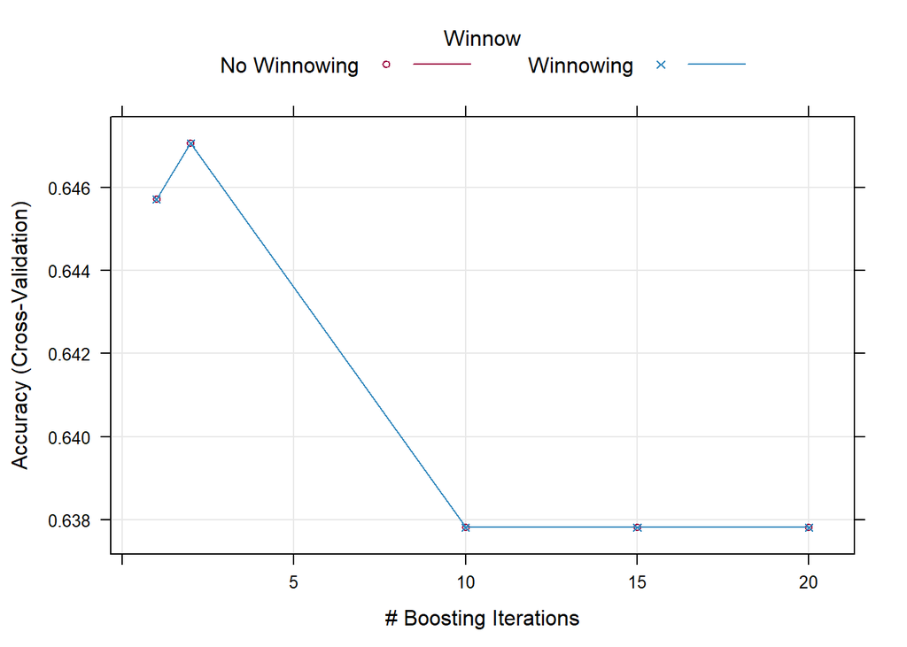

```r
trellis.par.set(caretTheme())
plot(C5model)
```

Método C5.0 com função treino execução

```r
C5pred <- predict(C5model, tstSet)

table(C5pred)

results.df <- rbind(results.df, allcrosstabmeasures(tst_labels, C5pred, "C5.0 with train caret "))
results.df
```

Matriz de confusão do método C5.0 com funcao treino:

```
             | Predicted
        Real |       Sim |       Nao | Row Total |
-------------|-----------|-----------|-----------|
         Sim |       231 |       488 |       719 |
             |     0.063 |     0.133 |           |
-------------|-----------|-----------|-----------|
         Nao |       498 |      2442 |      2940 |
             |     0.136 |     0.667 |           |
-------------|-----------|-----------|-----------|
Column Total |       729 |      2930 |      3659 |
-------------|-----------|-----------|-----------|
```

### Método C5.0 with adaptative boosting

```r
## C5.0 with adaptative boosting

set.seed(123)

boost100.model <- C5.0(x = trainSet[,c(1:10)],trainSet$Responded, trials = 100)

summary(boost100.model)

boost100.pred <- predict(boost100.model,tstSet)

results.df <- rbind(results.df,allcrosstabmeasures(tst_labels,boost100.pred,"C5.0 with adaptative boosting "))
results.df
```

Matriz de confusão do método C5.0 com adaptative boosting:

```
             | Predicted
        Real |       Sim |       Nao | Row Total |
-------------|-----------|-----------|-----------|
         Sim |       253 |       466 |       719 |
             |     0.069 |     0.127 |           |
-------------|-----------|-----------|-----------|
         Nao |       616 |      2324 |      2940 |
             |     0.168 |     0.635 |           |
-------------|-----------|-----------|-----------|
Column Total |       869 |      2790 |      3659 |
-------------|-----------|-----------|-----------|
```

Com a matrix de custos a ideia é tentar melhorar as previsões atribuindo custos a previsões menos desejadas. A ideia é atribuir um custo superior quando ele considera um cliente que respondeu a uma campanha na realidade como não ter respondido.

```r
set.seed(123)


cost.matrix <- matrix(c(
  0, 1,
  4, 0
),2,2, byrow=TRUE)

rownames(cost.matrix) <- colnames(cost.matrix) <- levels(trainSet$Responded)

cost.matrix

fitControl <- trainControl(method="repeatedcv", number=10, repeats=5)


grid <- expand.grid(winnow = c(TRUE,FALSE), trials = c(1,2,10,15,20), model = "tree",cost = cost.matrix)
grid

C5modelCosts <- train(Responded~.,data = trainSet,
                 method = "C5.0Cost",
                 metric = "Accuracy",
                 trControl = fitControl,
                 tuneGrid = grid)

C5modelCosts

C5predCosts <- predict(C5modelCosts,tstSet)

results.df <- rbind(results.df,allcrosstabmeasures(tst_labels,C5predCosts,"C5.0 with costs "))
results.df
```

Matriz de confusão do método C5.0 com matriz de custos:

```
             | Predicted
        Real |       Sim |       Nao | Row Total |
-------------|-----------|-----------|-----------|
         Sim |       276 |       443 |       719 |
             |     0.075 |     0.121 |           |
-------------|-----------|-----------|-----------|
         Nao |       677 |      2263 |      2940 |
             |     0.185 |     0.618 |           |
-------------|-----------|-----------|-----------|
Column Total |       953 |      2706 |      3659 |
-------------|-----------|-----------|-----------|
```

### Método Naive Bayes

```r
## Naive Bayes

set.seed(123)

modelLookup(model = "nb")

Bayesmodel <-train(trainSet[,c(1:10)], y = trainSet$Responded,
                    method = "nb",
                    tuneGrid = data.frame(fL=1,usekernel=FALSE,adjust=1),
                    trControl = ctrl)

Bayespred <- predict(Bayesmodel,tstSet)

results.df <- rbind(results.df,allcrosstabmeasures(tst_labels,Bayespred,"Naive Bayes"))
results.df
```

Matriz de confusão do método Naive Bayes:

```
             | Predicted
        Real |       Sim |       Nao | Row Total |
-------------|-----------|-----------|-----------|
         Sim |       145 |       574 |       719 |
             |     0.040 |     0.157 |           |
-------------|-----------|-----------|-----------|
         Nao |       529 |      2411 |      2940 |
             |     0.145 |     0.659 |           |
-------------|-----------|-----------|-----------|
Column Total |       674 |      2985 |      3659 |
-------------|-----------|-----------|-----------|
```

### Método Random Forest

```r
set.seed(123)

modelLookup(model = "rf")

control <- trainControl(method = "repeatedcv", number = 10, repeats = 3, search  ="grid")

mtry <- round(sqrt(ncol(trainSet)),0)

rfmodel <- train(Responded~.,
                 data=trainSet,
                 method = "rf",
                 tuneGrid = expand.grid(.mtry=1:15),
                 trControl=control,
                 ntree=100)
```

```r
print(rfmodel)
```

[output not shown]

```r
plot(rfmodel)
```

[output not shown]

```r
varImp(rfmodel)
```

[output not shown]

Método Random Forest execução do modelo

```r
rfpredict <- predict(rfmodel,newdata = tstSet,type = 'raw')
results.df <- rbind(results.df,allcrosstabmeasures(tst_labels,rfpredict,"Random Forest"))
results.df
```

Matriz de confusão do método Random Forest:

```
             | Predicted
        Real |       Sim |       Nao | Row Total |
-------------|-----------|-----------|-----------|
         Sim |       114 |       605 |       719 |
             |     0.031 |     0.165 |           |
-------------|-----------|-----------|-----------|
         Nao |       265 |      2675 |      2940 |
             |     0.072 |     0.731 |           |
-------------|-----------|-----------|-----------|
Column Total |       379 |      3280 |      3659 |
-------------|-----------|-----------|-----------|
```

### Método Logistic regression

```r
set.seed(123)

modelLookup(model = "glm")

crtl <- trainControl(method = 'cv', number = 3)

glmodel <- train(Responded~.,
                 data= trainSet,
                 method = 'glm',
                 trControl = crtl)

summary(glmodel)

glmpred <- predict(glmodel, newdata = tstSet)
results.df <- rbind(results.df,allcrosstabmeasures(tst_labels,glmpred,"Logistic regression"))
results.df
```

Matriz de confusão do método Logistic regression:

```
             | Predicted
        Real |       Sim |       Nao | Row Total |
-------------|-----------|-----------|-----------|
         Sim |       123 |       596 |       719 |
             |     0.034 |     0.163 |           |
-------------|-----------|-----------|-----------|
         Nao |       452 |      2488 |      2940 |
             |     0.124 |     0.680 |           |
-------------|-----------|-----------|-----------|
Column Total |       575 |      3084 |      3659 |
-------------|-----------|-----------|-----------|
```

### Método K-Nearest neighbours

```r
set.seed(123)

modelLookup(model = "knn")

knnmodel <- train(Responded~.,
                  data = trainSet,
                  method = 'knn',
                  tuneGrid = expand.grid(k = seq(1,100,2)),
                  metric = 'Accuracy',
                  trControl = crtl)

knnpred <- predict(knnmodel,newdata = tstSet, type = "raw")

results.df <- rbind(results.df,allcrosstabmeasures(tst_labels,knnpred,"K-Nearest neighbours"))
results.df
```

Matriz de confusão do método K-Nearest neighbours:

```
             | Predicted
        Real |       Sim |       Nao | Row Total |
-------------|-----------|-----------|-----------|
         Sim |       202 |       517 |       719 |
             |     0.055 |     0.141 |           |
-------------|-----------|-----------|-----------|
         Nao |       690 |      2250 |      2940 |
             |     0.189 |     0.615 |           |
-------------|-----------|-----------|-----------|
Column Total |       892 |      2767 |      3659 |
-------------|-----------|-----------|-----------|
```

### Método Support Vector Machine (SVM) LINEAR

```r
set.seed(123)

modelLookup(model = "svmLinear2")

svmodel <- train(Responded~.,
                 data = trainSet,
                 method = 'svmLinear2',
                 metric = 'Accuracy',
                 maximize = FALSE,
                 tuneLength = 15,
                 trControl = crtl)

svpred <- predict(svmodel,newdata = tstSet)

results.df <- rbind(results.df,allcrosstabmeasures(tst_labels,svpred,"Support Vector Machine (SVM) - Linear"))
results.df
```

[output not shown]

### Método Support Vector Machine (SVM) RADIAL

```r
set.seed(123)

modelLookup(model = "svmRadial")

grid <- expand.grid(sigma = c(.01,.015, 0.2), C = c(0.75, 0.9, 1,1.1,1.25))
svmodelradial <- train(Responded~.,
                 data = trainSet,
                 method = 'svmRadial',
                 PreProc = c("center","scale"),
                 metric = 'Accuracy',
                 maximize = FALSE,
                 tuneGrid = grid,
                 trControl = crtl)

svpredradial <- predict(svmodelradial,newdata = testSet)

results.df <- rbind(results.df,allcrosstabmeasures(test_Labels,svpredradial,"Support Vector Machine (SVM) - Radial"))
results.df
```

[output not shown]

### Método neural network

```r
set.seed(123)

nnetGrid <- expand.grid(.decay = c(0.1,0.2,0.3,0.4,0.5,0.6,0.7,0.8,0.9,1.0,1.1), size = (1:10))
nnetGrid <- expand.grid(decay = c(0, 0.01, .1),
                        size = c(1:10))

nnmodel <- train(Responded~.,
                 data = trainSet,
                 method = 'nnet',
                 metric = 'Accuracy',
                 tuneGrid = nnetGrid,
                 trace = FALSE,
                 maxit = 1000,
                 preProc = c("center","scale"),
                 trControl = crtl)

nnpred <- predict(nnmodel,newdata = tstSet)

results.df <- rbind(results.df,allcrosstabmeasures(tst_labels,nnpred,"Neural network"))
results.df
```

## 5.Análise do resultado dos modelos de classificação.

**True positive** e **true negative** são as observacões que foram corretamente previstas. a ideia aqui é minimizar os “false positive” e os “false negative”, sendo que o mais importante é reduzir o risco de perder negócio com a classificação errada, com a identificação de clientes que não iriam responder à campanha quando o resultado era na realidade positivo.

**True Positives** (TP) - Estes valores são valores da classe “Sim” que foram corretamente previstos.

**True Negatives** (TN) - Sao os valores da classe “Não” que foram corretamente previstos.

Os falsos positivos e os falso negativos são valores que ocorrem quando o modelo classifica as classes erradamente e de forma contrária ao real

**False Positives** (FP) - As ocorrências em que se obtem “Sim” na previsao do modelo mas na realidade sao “Não”.

**False Negatives** (FN) - Ao contrario dos falsos positivos, aqui a previsao originada e o “Não” mas deveria ter sido “Sim”.

Com estes parâmetros da matriz de confusão, conseguimos avaliar vários parâmetros dos modelos, tal como, *Accuracy*, *Precision*, *Recall* e *F1 score*.

A *Accuracy* é uma medida de performance do modelo que e um racio entre os valores corretamente previstos tendo em conta o número total de observacões. Esta medida é boa na avaliação de modelos equilibrados/balanceados, modelos que se obtem o mesmo número de falso positivos e falso negativos. Desta forma e como não é o caso, é necessario avaliar com outras medidas.

*Accuracy = TP+TN/TP+FP+FN+TN*

*Precision* - Indica o racio de valores positivos corretamente classificados tendo em conta o total de observacões positivas.

*Precision = TP/TP+FP*

*Recall* (Sensitivity) - Indica o racio de observacões corretamente previstas e todas as observacões da classe. Vai indicar quantos dos “Sim” foram corretamente classificados.

*Recall = TP/TP+FN*

*F1 score* - Esta medida e uma media pesada entre a Precision e a Recall, tendo em conta ambos os falsos positivos e os falsos negativos. Esta medida podera ser a mais acertada, principalmente no caso de termos classes desbalanceadas.

*F1 Score = 2 x (Recall x Precision) / (Recall + Precision)*

Resultados obtidos correndo os algoritmos classificação:

```
                         model    accuracy  recall    precision   f1    kappa   fpr
                  C5.0 Classif.   0.660     0.392     0.259       0.312 0.099   0.274
         C5.0 with train caret    0.731     0.321     0.317       0.319 0.151   0.169
 C5.0 with adaptative boosting    0.704     0.352     0.291       0.319 0.132   0.210
               C5.0 with costs    0.694     0.384     0.290       0.330 0.137   0.230
                   Naive Bayes    0.699     0.202     0.215       0.208 0.022   0.180
                 Random Forest    0.762     0.159     0.301       0.208 0.083   0.090
           Logistic regression    0.714     0.171     0.214       0.190 0.019   0.154
          K-Nearest neighbours    0.670     0.281     0.226       0.251 0.042   0.235
                Neural network    0.654     0.328     0.231       0.271 0.053   0.267
```

### Avaliação dos modelos

Devido ao grande desbalanceamento dos dados podemos observar que os valor obtidos de nas medidas de análise são muito baixos.

. A medida de *accuracy* encontra-se entre os 65% e 76% . A medida de *recall* encontra-se entre os 16% e 39% . A medida de *precision* encontra-se entre os 22% e 32% . A medida de *f1* encontra-se entre os 19% e 33%

Nesta avaliação os métodos de classificação o método que apresentou melhores resultados foi o:

```
                         model    accuracy  recall    precision   f1    kappa   fpr
               C5.0 with costs    0.694     0.384     0.290       0.330 0.137   0.230
```

Apesar de não ser o método que apresentou a melhor *accuracy*, foi o que mostrou melhores resultados no *score f1*, que será a variável mais interessante no caso dos dados aqui analisados.

## 7. Para uma segunda classificação dos clientes, forma usados os dados do *score RFM*, em que estes dados númericos forma convertidos para fatores de acordo com uma regra definida abaixo.

Ao categoriazar os clientes pelo valor de RFM atribuido, podemos tentar prever o tipo dos clientes novos.

Os factores da classe a prever foram criados seguindo a seguinte regra:

Com um score de *RFM* inferior ou igual a 233, consideramos um cliente **esporádico.** Com um score de *RFM* entre 234 e 443, consideramos um cliente **regular.** Com um score de *RFM* superior ou igual a 444, consideramos um cliente **frequente.**

```r
table(df_card$rfm_score)
```

```
##
## 111 112 113 114 115 121 122 123 124 125 131 132 133 134 135 141 142 143
## 825 370 219  96  35 166  96  71  47  16   5  13  24  39  16   1   1  12
## 144 145 151 152 153 154 155 211 212 213 214 215 221 222 223 224 225 231
##  21   7  14  35  37 226  73 192 201 191 148  81  91 185 218 193  92  52
## 232 233 234 235 241 242 243 244 245 251 252 253 254 255 311 312 313 314
## 122 140 138  74  18  53  52  51  27   3  11  12  18  47 198 138 151 126
## 315 321 322 323 324 325 331 332 333 334 335 341 342 343 344 345 351 352
##  72  77 135 188 137  80  67 158 149 133  67  26  43  61  58  41   4   6
## 353 354 355 411 412 413 414 415 421 422 423 424 425 431 432 433 434 435
##  20  39 133 207 136 130  94  64  74 139 140 117  63  65 105 114 113  60
## 441 442 443 444 445 451 452 453 454 455 511 512 513 514 515 521 522 523
##  18  47  49  58  42  24  14  28  85 422 236 126 121  88  68  73 117 108
## 524 525 531 532 533 534 535 541 542 543 544 545 551 552 553 554 555
## 119  57  44  99 104  90  55  20  25  35  40  29  29  29  48 120 729
```

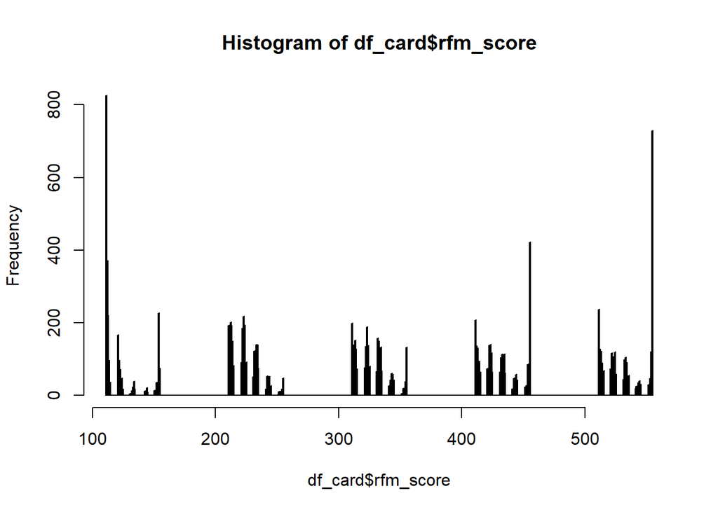

```r
hist(df_card$rfm_score,breaks = seq(min(df_card$rfm_score), max(df_card$rfm_score), length.out = df_card$rfm_score))
```

```r
summary(df_card)
```

```
##           City          Region           Gender      MaritalStatus
##  Catburg    :2073   Central:6084   Feminino :6077   Casado  :4010
##  Foxton     :2044   Eastern:6115   Masculino:6122   Solteiro:4110
##  Kingsville :2104                                   Outro   :4079
##  Princeton  :1975
##  Queensbury :2005
##  Ravensville:1998
##  HasChildren  NumChildren    YoungestChild     rfm_score
##  Sim:6880    Min.   :0.000   Min.   : 0.00   Min.   :111.0
##  Nao:5319    1st Qu.:0.000   1st Qu.: 2.00   1st Qu.:214.0
##              Median :1.000   Median :10.00   Median :325.0
##              Mean   :1.141   Mean   :11.18   Mean   :330.3
##              3rd Qu.:2.000   3rd Qu.:17.00   3rd Qu.:454.0
##              Max.   :7.000   Max.   :66.00   Max.   :555.0
##       age          clientYears    Responded
##  Min.   : 23.00   Min.   :13.00   Sim:2399
##  1st Qu.: 46.00   1st Qu.:15.00   Nao:9800
##  Median : 53.00   Median :15.00
##  Mean   : 53.57   Mean   :15.27
##  3rd Qu.: 60.00   3rd Qu.:16.00
##  Max.   :110.00   Max.   :17.00
```

```r
df_card$rfm_score_cat <- case_when(df_card$rfm_score <= 233 ~ 'Sporadically',
                  between(df_card$rfm_score, 234, 443) ~ 'Regular',
                  df_card$rfm_score >= 444 ~ 'Frequent'
                  )

df_card$rfm_score_cat <- as.factor(df_card$rfm_score_cat)

summary(df_card)
```

```
##           City          Region           Gender      MaritalStatus
##  Catburg    :2073   Central:6084   Feminino :6077   Casado  :4010
##  Foxton     :2044   Eastern:6115   Masculino:6122   Solteiro:4110
##  Kingsville :2104                                   Outro   :4079
##  Princeton  :1975
##  Queensbury :2005
##  Ravensville:1998
##  HasChildren  NumChildren    YoungestChild     rfm_score
##  Sim:6880    Min.   :0.000   Min.   : 0.00   Min.   :111.0
##  Nao:5319    1st Qu.:0.000   1st Qu.: 2.00   1st Qu.:214.0
##              Median :1.000   Median :10.00   Median :325.0
##              Mean   :1.141   Mean   :11.18   Mean   :330.3
##              3rd Qu.:2.000   3rd Qu.:17.00   3rd Qu.:454.0
##              Max.   :7.000   Max.   :66.00   Max.   :555.0
##       age          clientYears    Responded       rfm_score_cat
##  Min.   : 23.00   Min.   :13.00   Sim:2399   Frequent    :3282
##  1st Qu.: 46.00   1st Qu.:15.00   Nao:9800   Regular     :4546
##  Median : 53.00   Median :15.00              Sporadically:4371
##  Mean   : 53.57   Mean   :15.27
##  3rd Qu.: 60.00   3rd Qu.:16.00
##  Max.   :110.00   Max.   :17.00
```

```r
new_df_card <- df_card[,c(1:7,9,10,12)]
str(new_df_card)
```

```
## Classes 'data.table' and 'data.frame':   12199 obs. of  10 variables:
##  $ City         : Factor w/ 6 levels "Catburg","Foxton",..: 3 1 4 2 5 3 3 5 5 2 ...
##  $ Region       : Factor w/ 2 levels "Central","Eastern": 1 2 1 2 1 1 1 1 1 2 ...
##  $ Gender       : Factor w/ 2 levels "Feminino","Masculino": 1 1 2 1 2 1 1 2 1 2 ...
##  $ MaritalStatus: Factor w/ 3 levels "Casado","Solteiro",..: 2 2 3 1 1 3 3 1 3 2 ...
##  $ HasChildren  : Factor w/ 2 levels "Sim","Nao": 1 1 2 1 1 1 2 1 1 2 ...
##  $ NumChildren  : num  1 1 0 1 1 3 0 2 1 0 ...
##  $ YoungestChild: num  0 6 30 21 6 0 10 0 15 11 ...
##  $ age          : num  45 52 74 59 53 43 54 43 59 52 ...
##  $ clientYears  : num  14 15 15 14 15 17 13 15 15 15 ...
##  $ rfm_score_cat: Factor w/ 3 levels "Frequent","Regular",..: 1 2 1 1 1 2 1 2 1 3 ...
##  - attr(*, ".internal.selfref")=<externalptr>
```

```r
attach(new_df_card)
```

Este clustering manual vai-nos permitir ter um melhor conhecimento dos novos clientes, prevendo a sua possível categoria de cliente.

## Holdout stratified, neste caso nao consideramos a necessidade de fazer o oversampling pois os valores sao relativamente equilibrados.

```r
set.seed(123)

table(new_df_card$rfm_score_cat)
```

```
##
##     Frequent      Regular Sporadically
##         3282         4546         4371
```

```r
round(prop.table(table(new_df_card$rfm_score_cat))*100, digits = 2)
```

```
##
##     Frequent      Regular Sporadically
##        26.90        37.27        35.83
```

```r
##create of stratified train/test partitions
train.idx <- createDataPartition(new_df_card$rfm_score_cat, p = 0.7, list = F)

trainSet <- new_df_card[ train.idx, ]
tstSet <-   new_df_card[-train.idx, ]

table(trainSet$rfm_score_cat)
```

```
##
##     Frequent      Regular Sporadically
##         2298         3183         3060
```

```r
round(prop.table(table(trainSet$rfm_score_cat))*100, digits = 2)
```

```
##
##     Frequent      Regular Sporadically
##        26.91        37.27        35.83
```

```r
train_labels <- trainSet$rfm_score_cat
tst_labels <- tstSet$rfm_score_cat

round(prop.table(table(train_labels))*100, digits = 2)
```

```
## train_labels
##     Frequent      Regular Sporadically
##        26.91        37.27        35.83
```

```r
round(prop.table(table(tst_labels))*100, digits = 2)
```

```
## tst_labels
##     Frequent      Regular Sporadically
##        26.90        37.26        35.84
```

```r
ncols <- dim(trainSet)[2]
ctrl <- trainControl(method = "cv", number = 10)
```

## 8. Algoritmos de classificação para segunda classificação

### Método de classificação C5.0

```r
set.seed(123)

modelLookup(model = "C5.0") ## ver o que o model pede

C5Model <- C5.0(rfm_score_cat~.,data = trainSet)

summary(C5Model)

C5Predict <- predict(C5Model,newdata = tstSet,type = "class")

results.new_df <- rbind(results.new_df,allcrosstabmeasures(tst_labels,C5Predict,"C5.0 Classif."))
results.new_df
```

Matriz de confusão do método de classificação C5.0

```
             | Predicted
        Real |     Frequent |      Regular | Sporadically |    Row Total |
-------------|--------------|--------------|--------------|--------------|
    Frequent |          160 |          416 |          408 |          984 |
             |        0.044 |        0.114 |        0.112 |              |
-------------|--------------|--------------|--------------|--------------|
     Regular |          220 |          589 |          554 |         1363 |
             |        0.060 |        0.161 |        0.151 |              |
-------------|--------------|--------------|--------------|--------------|
Sporadically |          193 |          541 |          577 |         1311 |
             |        0.053 |        0.148 |        0.158 |              |
-------------|--------------|--------------|--------------|--------------|
Column Total |          573 |         1546 |         1539 |         3658 |
-------------|--------------|--------------|--------------|--------------|
```

### Método de classificação C5.0 com adpatative boosting

```r
set.seed(123)

boost100.model <- C5.0(rfm_score_cat~.,data = trainSet, trials = 100)

summary(boost100.model)

boost100.pred <- predict(boost100.model,tstSet)

results.new_df <- rbind(results.new_df,allcrosstabmeasures(tst_labels,boost100.pred,"C5.0 with adaptative boosting "))
results.new_df
```

Matriz de confusão do método de classificação C5.0 com adpatative boosting

```
             | Predicted
        Real |     Frequent |      Regular | Sporadically |    Row Total |
-------------|--------------|--------------|--------------|--------------|
    Frequent |          160 |          416 |          408 |          984 |
             |        0.044 |        0.114 |        0.112 |              |
-------------|--------------|--------------|--------------|--------------|
     Regular |          220 |          589 |          554 |         1363 |
             |        0.060 |        0.161 |        0.151 |              |
-------------|--------------|--------------|--------------|--------------|
Sporadically |          193 |          541 |          577 |         1311 |
             |        0.053 |        0.148 |        0.158 |              |
-------------|--------------|--------------|--------------|--------------|
Column Total |          573 |         1546 |         1539 |         3658 |
-------------|--------------|--------------|--------------|--------------|
```

### Método de classificação Naive Bayes.

```r
## Naive Bayes

set.seed(123)

Bayesmodel <-train(rfm_score_cat~.,data = trainSet,
                    method = "nb",
                    tuneGrid = data.frame(fL=0,usekernel=FALSE,adjust=1),
                    trControl = ctrl)

Bayespred <- predict(Bayesmodel,tstSet)

results.new_df <- rbind(results.new_df,allcrosstabmeasures(tst_labels,Bayespred,"Naive Bayes"))
results.new_df
```

Matriz de confusão do método de classificação C5.0 com Naive Bayes.

```
             | Predicted
        Real |     Frequent |      Regular | Sporadically |    Row Total |
-------------|--------------|--------------|--------------|--------------|
    Frequent |            0 |          434 |          550 |          984 |
             |        0.000 |        0.119 |        0.150 |              |
-------------|--------------|--------------|--------------|--------------|
     Regular |            0 |          565 |          798 |         1363 |
             |        0.000 |        0.154 |        0.218 |              |
-------------|--------------|--------------|--------------|--------------|
Sporadically |            1 |          524 |          786 |         1311 |
             |        0.000 |        0.143 |        0.215 |              |
-------------|--------------|--------------|--------------|--------------|
Column Total |            1 |         1523 |         2134 |         3658 |
-------------|--------------|--------------|--------------|--------------|
```

### Método de classificação K-Nearest neighbours.

```r
set.seed(123)

knnmodel <- train(rfm_score_cat~.,
                  data = trainSet,
                  method = 'knn',
                  tuneGrid = expand.grid(k = seq(1,100,2)),
                  metric = 'Accuracy',
                  trControl = ctrl)

knnpred <- predict(knnmodel,newdata = tstSet, type = "raw")
table(knnpred)

results.new_df <- rbind(results.new_df,allcrosstabmeasures(tst_labels,knnpred,"K-Nearest neighbours"))
results.new_df
```

Matriz de confusão do método de classificação K-Nearest neighbours.

```
             | Predicted
        Real |     Frequent |      Regular | Sporadically |    Row Total |
-------------|--------------|--------------|--------------|--------------|
    Frequent |           22 |          512 |          450 |          984 |
             |        0.006 |        0.140 |        0.123 |              |
-------------|--------------|--------------|--------------|--------------|
     Regular |           44 |          683 |          636 |         1363 |
             |        0.012 |        0.187 |        0.174 |              |
-------------|--------------|--------------|--------------|--------------|
Sporadically |           41 |          621 |          649 |         1311 |
             |        0.011 |        0.170 |        0.177 |              |
-------------|--------------|--------------|--------------|--------------|
Column Total |          107 |         1816 |         1735 |         3658 |
-------------|--------------|--------------|--------------|--------------|
```

### Método de classificação Suport Vector Machine com o method Radial.

```r
set.seed(123)
grid <- expand.grid(sigma = c(.01,.015, 0.2), C = c(0.75, 0.9, 1,1.1,1.25))
svmodelradial <- train(rfm_score_cat~.,
                 data = trainSet,
                 method = 'svmRadial',
                 PreProc = c("center","scale"),
                 metric = 'Accuracy',
                 maximize = FALSE,
                 tuneGrid = grid,
                 trControl = ctrl)

svpredradial <- predict(svmodelradial,newdata = tstSet)
table(svpredradial)

results.new_df <- rbind(results.new_df,allcrosstabmeasures(tst_labels,svpredradial,"Support Vector Machine (SVM) - Radial"))
results.new_df
```

Matriz de confusão do método de classificação Suport Vector Machine com o method Radial.

```
             | Predicted
        Real |     Frequent |      Regular | Sporadically |    Row Total |
-------------|--------------|--------------|--------------|--------------|
    Frequent |           76 |          478 |          430 |          984 |
             |        0.021 |        0.131 |        0.118 |              |
-------------|--------------|--------------|--------------|--------------|
     Regular |          112 |          651 |          600 |         1363 |
             |        0.031 |        0.178 |        0.164 |              |
-------------|--------------|--------------|--------------|--------------|
Sporadically |          104 |          619 |          588 |         1311 |
             |        0.028 |        0.169 |        0.161 |              |
-------------|--------------|--------------|--------------|--------------|
Column Total |          292 |         1748 |         1618 |         3658 |
-------------|--------------|--------------|--------------|--------------|
```

Com os métodos Neural Network e Support Vector Machine (SVM) LINEAR, não foi possível classificar pois nunca foi capaz de prever o atributo do tipo frequente, logo não consideramos na nossa análise.

## Avaliacao dos modelos para previsao do atributo de cliente baseado no RFM.

```
                                  model   accuracy  recall    precision   f1    kappa   fpr
                          C5.0 Classif.   0.362     0.163     0.279       0.206 0.204   0.161
         C5.0 with adaptative boosting    0.362     0.163     0.279       0.206 0.204   0.161
                           Naive Bayes    0.369     0.000     0.000       0.000 0.253   0.000
                  K-Nearest neighbours    0.370     0.022     0.206       0.040 0.220   0.032
 Support Vector Machine (SVM) - Radial    0.359     0.077     0.260       0.119 0.200   0.082
```

### Avaliação dos modelos

Nesta avaliação os métodos de classificação o método que apresentou melhores resultados foi o:

```
                          model    accuracy  recall    precision   f1    kappa   fpr
  C5.0 with adaptative boosting    0.362     0.163     0.279       0.206 0.204   0.161
```

Apesar de não ser o método que apresentou a melhor *accuracy*, foi o que mostrou melhores resultados no *score f1*, que será a variável mais interessante no caso dos dados aqui analisados.

## References

Birant, Derya. 2011. “Data Mining Using RFM Analysis.” *Knowledge-Oriented Applications in Data Mining*, no. iii: 91–108. doi:10.5772/13683.

Fan, Yi. 2016. “RFM Analysis in R MATH 3201 DATAMINING FOUNDATION.” http://mercury.webster.edu/aleshunas/Support Materials/Analysis/Fan-Yi Fan{\_}MATH3210{\_}Final Project 1.pdf.